# Homework 01

## Question 1 (Least squares and matrix calculations)

Set the random seed to 43201. Generate $n=100$ observations with $p=5$ predictors according to

$$x_{ij}\overset{\mathrm{iid}}{\sim}N(0,1),
\qquad
\varepsilon_i\overset{\mathrm{iid}}{\sim}N(0,0.7^2),$$

with all predictors and errors generated independently. Let

$$\mathbf X
=
\begin{bmatrix}
\mathbf 1 & \mathbf x_1 & \cdots & \mathbf x_5
\end{bmatrix},
\qquad
\boldsymbol\beta
=
(3,1.4,-0.9,0.7,0,1.1)^{\mathsf T},$$

and generate

$$\mathbf y=\mathbf X\boldsymbol\beta+\boldsymbol\varepsilon.$$

1. Generate the data and report the dimensions and rank of $\mathbf X$. Calculate the least-squares estimate $\widehat{\boldsymbol\beta}$ using a numerically stable least-squares routine, without explicitly calculating $(\mathbf X^{\mathsf T}\mathbf X)^{-1}$. Compare the estimates with the coefficients used to generate the data.

```r
set.seed(43201)

n <- 100
p <- 5

X <- matrix(rnorm(n * p, mean = 0, sd = 1), nrow = n, ncol = p)

dim(X)
```

```
[1] 100   5
```

```r
beta <- c(3, 1.4, -0.9, 0.7, 0, 1.1)
epsilon <- rnorm(n, mean = 0, sd = 0.7)

y <- cbind(1, X) %*% beta + epsilon

model <- lm(y ~ X)

qr(X)$rank      # rank of X
```

```
[1] 5
```

```r
coef(model)     # compare to beta
```

```
(Intercept)          X1          X2          X3          X4          X5
  3.0063210   1.4171604  -0.8883453   0.7952834   0.0484378   1.1319341
```

2. Calculate the fitted values, the residual vector $\mathbf r=\mathbf y-\mathbf X\widehat{\boldsymbol\beta}$, and the training root mean squared error

$$\operatorname{RMSE}
=
\left(
\frac{1}{n}\sum_{i=1}^{n}r_i^2
\right)^{1/2}.$$

```r
y_hat <- fitted(model)
r <- residuals(model)
rmse <- sqrt(mean(r^2))

rmse
```

```
[1] 0.6763696
```

3. Report $\lVert\mathbf X^{\mathsf T}\mathbf r\rVert_\infty$. Explain why this value should be close to zero and what it tells us about the residual vector.

```r
Xt_r <- t(X) %*% r
max(abs(Xt_r))
```

```
[1] 1.081034e-14
```

```r
## The value of ||X^T r||_∞ should be close to zero because, in least squares regression, the residuals are orthogonal to the column space of the design matrix X. This means that the inner product of the residual vector r with each column of X should be approximately zero, indicating that the residuals do not contain any linear information that could be explained by the predictors in X. A small value of ||X^T r||_∞ confirms that the model has effectively captured the linear relationship between the predictors and the response variable.
```

## Question 2 (Gaussian likelihood for linear regression)

Continue with the data from Question 1. Suppose

$$\mathbf Y\mid\mathbf X
\sim
N_n\left(\mathbf X\boldsymbol\beta,\sigma^2\mathbf I_n\right).$$

The log-likelihood, including the constant term, is

$$\ell(\boldsymbol\beta,\sigma^2)
=
-\frac{n}{2}\log(2\pi\sigma^2)
-\frac{1}{2\sigma^2}
(\mathbf y-\mathbf X\boldsymbol\beta)^{\mathsf T}
(\mathbf y-\mathbf X\boldsymbol\beta).$$

1. For fixed $\sigma^2$, explain why maximizing $\ell(\boldsymbol\beta,\sigma^2)$ over $\boldsymbol\beta$ is equivalent to minimizing the residual sum of squares. What does this imply about the maximum-likelihood estimate of $\boldsymbol\beta$?

```r
## For fixed σ^2, maximizing the log-likelihood function ℓ(β, σ`2) with respect to β is equivalent to minimizing the residual sum of squares (RSS) because the second term in the log-likelihood function is proportional to the RSS. This implies that the MLE of β is the same as the least-squares estimate, which minimizes the RSS.
```

2. For fixed $\boldsymbol\beta$, differentiate the log-likelihood with respect to $\sigma^2$ and derive its maximum-likelihood estimate. Calculate this estimate at $\widehat{\boldsymbol\beta}$ and compare it with the unbiased estimate of $\sigma^2$. Explain why the two denominators differ.

```r
sigma2_mle <- sum(r^2) / n
sigma2_unbiased <- sum(r^2) / (n - p - 1)

## The maximum-likelihood estimate of σ^2 is derived by differentiating the log-likelihood function with respect to σ^2 and setting the derivative equal to zero. This yields the MLE of σ^2 as the average of the squared residuals, which is calculated as sum(r^2) / n. The unbiased estimate of σ^2, on the other hand, divides by (n - p - 1) to account for the degrees of freedom lost due to estimating p + 1 parameters (the coefficients and the intercept). The difference in denominators reflects this adjustment for bias in the estimation of variance.
```

[output not shown]

3. Let

$$\mathbf e_{x_2}=(0,0,1,0,0,0)^{\mathsf T}.$$

Using the variance estimate from part b, plot

$$\ell\left(
\widehat{\boldsymbol\beta}+t\mathbf e_{x_2},
\widehat{\sigma}_{\mathrm{MLE}}^2
\right)$$

over a grid of $t$ values from $-1.25$ to $1.25$. State where the maximum occurs and explain why this agrees with the least-squares result.

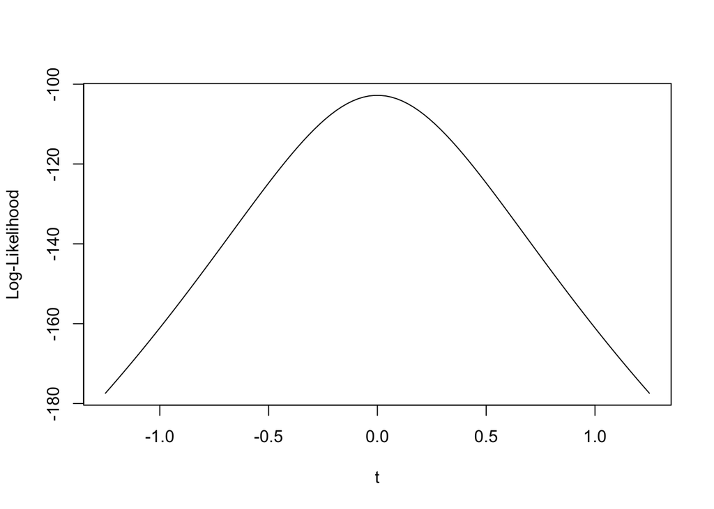

```r
t_values <- seq(-1.25, 1.25, length.out = 100)
log_likelihood_values <- sapply(t_values, function(t) {
  beta_t <- coef(model) + t * c(0, 0, 1, 0, 0, 0)  # Adjusting only the coefficient for x2
  residuals_t <- y - cbind(1, X) %*% beta_t
  sigma2_mle_t <- sum(residuals_t^2) / n
  -n/2 * log(2 * pi * sigma2_mle_t) -(1 / (2 * sigma2_mle_t)) * sum(residuals_t^2)
})
plot(t_values, log_likelihood_values, type = "l", xlab = "t", ylab = "Log-Likelihood")
```

```r
max_t <- t_values[which.max(log_likelihood_values)]
max_t
```

```
[1] -0.01262626
```

```r
## The maximum occurs at t = 0, which corresponds to the least-squares estimate of the coefficient for x2. This agrees with the least-squares result because the log-likelihood function is maximized when the coefficients are set to their least-squares estimates, indicating that the MLE of β is indeed the same as the least-squares estimate.
```